# Predicting Salary on Glassdoor

Olivia Wu

March 27, 2023

## Introduction

The purpose of this project is to develop a model that will predict salaries on Glassdoor.

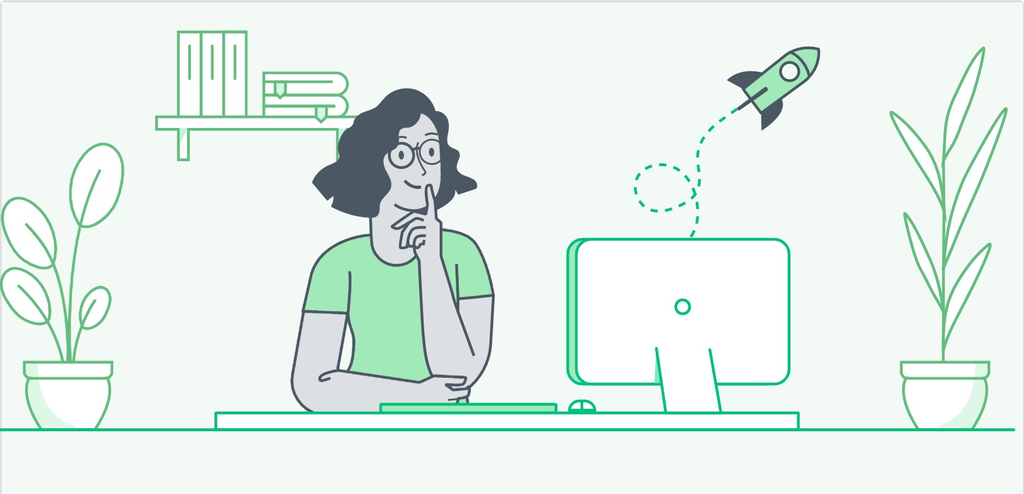

### What is Glassdoor?

Glassdoor is a digital platform that gathers company reviews and information from past and current employees anonymously. It acts as a job board where prospective employees can view company ratings, job postings, average salary range, benefits, and more. It also provides useful information like affiliated companies, HQ/company locations, interview ratings, and more. However recent controversies have caused the company to reveal the identities of users who leave negative reviews of former employers. While the reliability of the site remains questionable, it is nevertheless a useful source for reference when job hunting.

[figure not shown]

```r
knitr::include_graphics("C:/Users/olivi/Documents/ucsb winter 2023/pstat 131/final project/assets/images/2560px-Glassdoor_logo.svg.png")
```

```r
# ![Glassdoor logo](C:/Users/olivi/Documents/ucsb winter 2023/pstat 131/final project/assets/images/2560px-Glassdoor_logo.svg.png)
```

Glassdoor logo

### What are we trying to do?

A question we are more focused on asking is: what combination of factors results in the highest salary for separate positions on Glassdoor? The same job position could have varying salaries based on multiple factors like larger companies or different locations. I am interested in exploring what combination of these factors result in the highest salary. Our focus is on data science related positions as that is the most relevant to this class.

### Why?

When we perform job searches the biggest aim is always about money. We aim for the highest salary possible within our realm of qualifications and capabilities. Instead of having to search, compile, and compare each result one by one on an excel sheet, we can take the aggregate data and get a overview of the bigger picture. While sites like LinkedIn may be more useful for job searches, often times pay is not included in the job posting. Glassdoor gives us a better sense of what the company is like in terms of work environment, pay, and benefits.

## Data

### Loading Packages and Data

```r
library(tidymodels)
library(tidyverse)
library(tidyr)
library(ISLR)
library(ISLR2)
library(kknn)
library(glmnet)
library(modeldata)
library(ggthemes)
library(janitor)
library(naniar)
library(corrplot)
library(themis)
library(ggplot2)
tidymodels_prefer()

library(readr)
library(discrim)
library(forcats)
library(vip)
library(dplyr)
library(randomForest)
library(xgboost)
library(gsubfn) # for string extraction
library(stringr)
library(fastDummies)

# eda <- read.csv("C:/Users/olivi/Documents/ucsb winter 2023/pstat 131/final project/data/eda_data.csv")
# glassdoor_uncleaned <- read.csv("C:/Users/olivi/Documents/ucsb winter 2023/pstat 131/final project/data/glassdoor_jobs.csv")
```

```r
glassdoor <- read_csv("C:/Users/olivi/Documents/ucsb winter 2023/pstat 131/final project/data/processed/salary_data_cleaned.csv") %>% clean_names()

head(glassdoor)
```

| job_title | salary_estimate | job_description | rating | company_name | location | headquarters | size | founded | type_of_ownership | industry | sector | revenue | competitors | hourly | employer_provided | min_salary | max_salary | avg_salary | company_txt | job_state | same_state | age | python_yn | r_yn | spark | aws | excel |
| --- | --- | --- | --- | --- | --- | --- | --- | --- | --- | --- | --- | --- | --- | --- | --- | --- | --- | --- | --- | --- | --- | --- | --- | --- | --- | --- | --- |
| Data Scientist | $53K-$91K (Glassdoor est.) | Data Scientist\nLocation: Albuquerque, NM\nEducation Required: Bachelor’s degree required, preferably in math, engineering, business, or the sciences.\nSkills Required:\nBachelor’s Degree in relevant … | 3.8 | Tecolote Research\n3.8 | Albuquerque, NM | Goleta, CA | 501 to 1000 employees | 1973 | Company - Private | Aerospace & Defense | Aerospace & Defense | $50 to $100 million (USD) | -1 | 0 | 0 | 53 | 91 | 72.0 | Tecolote Research\n | NM | 0 | 47 | 1 | 0 | 0 | 0 | 1 |
| Healthcare Data Scientist | $63K-$112K (Glassdoor est.) | What You Will Do:\n\nI. General Summary\n\nThe Healthcare Data Scientist position will join our Advanced Analytics group at the University of Maryland Medical System (UMMS) in support of its strategic… | 3.4 | University of Maryland Medical System\n3.4 | Linthicum, MD | Baltimore, MD | 10000+ employees | 1984 | Other Organization | Health Care Services & Hospitals | Health Care | $2 to $5 billion (USD) | -1 | 0 | 0 | 63 | 112 | 87.5 | University of Maryland Medical System\n | MD | 0 | 36 | 1 | 0 | 0 | 0 | 0 |
| Data Scientist | $80K-$90K (Glassdoor est.) | KnowBe4, Inc. is a high growth information security company. We are the world's largest provider of new-school security awareness training and simulated phishing. KnowBe4 was created to help organizat… | 4.8 | KnowBe4\n4.8 | Clearwater, FL | Clearwater, FL | 501 to 1000 employees | 2010 | Company - Private | Security Services | Business Services | $100 to $500 million (USD) | -1 | 0 | 0 | 80 | 90 | 85.0 | KnowBe4\n | FL | 1 | 10 | 1 | 0 | 1 | 0 | 1 |
| Data Scientist | $56K-$97K (Glassdoor est.) | *Organization and Job ID**\nJob ID: 310709\n\nDirectorate: Earth & Biological Sciences\n\nDivision: Biological Sciences\n\nGroup: Exposure Science Team\n*Job Description**\nThe Biological System Scien… | 3.8 | PNNL\n3.8 | Richland, WA | Richland, WA | 1001 to 5000 employees | 1965 | Government | Energy | Oil, Gas, Energy & Utilities | $500 million to $1 billion (USD) | Oak Ridge National Laboratory, National Renewable Energy Lab, Los Alamos National Laboratory | 0 | 0 | 56 | 97 | 76.5 | PNNL\n | WA | 1 | 55 | 1 | 0 | 0 | 0 | 0 |
| Data Scientist | $86K-$143K (Glassdoor est.) | Data Scientist\nAffinity Solutions / Marketing Cloud seeks smart, curious, technically savvy candidates to join our cutting-edge data science team. We hire the best and brightest and give them the opp… | 2.9 | Affinity Solutions\n2.9 | New York, NY | New York, NY | 51 to 200 employees | 1998 | Company - Private | Advertising & Marketing | Business Services | Unknown / Non-Applicable | Commerce Signals, Cardlytics, Yodlee | 0 | 0 | 86 | 143 | 114.5 | Affinity Solutions\n | NY | 1 | 22 | 1 | 0 | 0 | 0 | 1 |
| Data Scientist | $71K-$119K (Glassdoor est.) | CyrusOne is seeking a talented Data Scientist who holds a range of data-focused skills both in technical and analytical domains. The ideal candidate is adept at processing, cleansing, and verifying th… | 3.4 | CyrusOne\n3.4 | Dallas, TX | Dallas, TX | 201 to 500 employees | 2000 | Company - Public | Real Estate | Real Estate | $1 to $2 billion (USD) | Digital Realty, CoreSite, Equinix | 0 | 0 | 71 | 119 | 95.0 | CyrusOne\n | TX | 1 | 20 | 1 | 0 | 0 | 1 | 1 |

This dataset was taken from the Kaggle dataset “[Salary Prediction](https://www.kaggle.com/datasets/thedevastator/jobs-dataset-from-glassdoor?resource=download&select=eda_data.csv)” and contains job postings from [glassdoor.com](https://www.glassdoor.com/member/home/index.htm) in 2017. It was scraped by Ramiro Gomez and is licensed to CC0 1.0 - Public Domain Dedication.

### Data Cleaning

i.e. variable selection

```r
# check how much data we have; output is formatted row col
dim(glassdoor) # 742 28
```

```
## [1] 742  28
```

```r
# checking number of unique classifications
glassdoor %>% distinct(job_title) %>% count() # 264
```

| n |
| --- |
| 264 |

```r
# reorder avg_salary to 1st column to make it easier to access and clean the column names
glassdoor <- glassdoor %>% select(c("avg_salary", "min_salary", "max_salary", "job_title", "rating", "size", "type_of_ownership", "industry", "revenue", "job_state", "age", "python_yn", "r_yn", "spark", "aws", "excel")) %>% clean_names()
```

After further work it appears that one of the observation had “Los Angeles” in `job_state` so we will need to take care of that as well.

```r
filterIndex = which(glassdoor$job_state == "Los Angeles")

glassdoor[filterIndex, ]$job_state = "CA"

# check that the observation is now correct
glassdoor[filterIndex, ]
```

| avg_salary | min_salary | max_salary | job_title | rating | size | type_of_ownership | industry | revenue | job_state | age | python_yn | r_yn | spark | aws | excel |
| --- | --- | --- | --- | --- | --- | --- | --- | --- | --- | --- | --- | --- | --- | --- | --- |
| 107.5 | 82 | 133 | Data Scientist | 3.6 | 1001 to 5000 employees | Company - Private | Industrial Manufacturing | $100 to $500 million (USD) | CA | 54 | 0 | 0 | 0 | 0 | 1 |

`hourly` and `employer_provided` have values of 0 so they do not provide useful information, so obviously those are removed as well. Whether a job applier lives in the same state is irrelevant to estimating salary, so we also remove `same_state`. `location` is given in `job_state` so it is redundant information.

`job_description` is helpful for getting a sense of the job responsibilities, and would be interesting to see some repeating key words that appear throughout different job descriptions. From a glance we can see many descriptions include desired qualifications or skills like bachelor’s degree in science/math, Tableau, Matlab, Python, SQL, C++, and so on. While it would be very informative to scrape the descriptions for words and separate them into another table, this could be another classification project in and of itself. We will simply use the data we currently have.

### Making Revenue a numeric variable

Revenue is given a range in text. To account for this we will split revenue into 2 columns: `revenue_low` and `revenue_high`. Fortunately for us this will be a easy process to automate, as the data was all entered in the same format.

```r
totalRow = 742

# replace " billion" with "000"
glassdoor$revenue <- sub(" billion", "000 million (USD)", glassdoor$revenue)

glassdoor$revenue <- sub("+ billion", "000 million (USD)", glassdoor$revenue)

# replace "Unknown / Non-Applicable" to "NA"
glassdoor$revenue <- sub("Unknown / Non-Applicable", "", glassdoor$revenue )

# split string to extract 2 numbers from the string
split2 = str_split(glassdoor$revenue, " to ")

# add columns with the extracted values
for (i in 1:totalRow)
{
  glassdoor$revenue_low[i] = extract_numeric(split2[[i]][1])
  glassdoor$revenue_high[i] = extract_numeric(split2[[i]][2])
}

# remove revenue from the dataset from list
glassdoor <- glassdoor %>% select(-revenue)
```

### Tidying Observations

I think it would be useful to see what the most common job positions being posted are, so we do just that here.

```r
agg_glassdoor <- glassdoor %>% group_by(job_title) %>% summarise(count = n(), avg_salary = mean(avg_salary)) %>%  arrange(desc(count))

agg_glassdoor %>% arrange(count)
```

| job_title | count | avg_salary |
| --- | --- | --- |
| Ag Data Scientist | 1 | 80.50 |
| Analytics Consultant | 1 | 66.50 |
| Assistant Director/Director, Office of Data Science | 1 | 53.00 |
| Associate Data Scientist/Computer Scientist | 1 | 81.50 |
| Associate Research Scientist I (Protein Expression and Production) | 1 | 87.50 |
| Associate Scientist | 1 | 81.50 |
| Associate Scientist / Sr. Associate Scientist, Antibody Discovery | 1 | 92.00 |
| Associate Scientist/Scientist, Process Analytical Technology - Small Molecule Analytical Chemistry | 1 | 125.00 |
| Big Data Engineer - Chicago - Future Opportunity | 1 | 100.00 |
| Business Data Analyst, SQL | 1 | 65.00 |

[output cut: 254 more lines]

```r
head(agg_glassdoor, 10)
```

| job_title | count | avg_salary |
| --- | --- | --- |
| Data Scientist | 131 | 106.18 |
| Data Engineer | 53 | 91.66 |
| Senior Data Scientist | 34 | 134.87 |
| Data Analyst | 15 | 66.30 |
| Senior Data Engineer | 14 | 121.93 |
| Senior Data Analyst | 12 | 83.42 |
| Lead Data Scientist | 8 | 161.25 |
| Marketing Data Analyst | 6 | 48.67 |
| Sr. Data Engineer | 6 | 115.00 |
| Machine Learning Engineer | 5 | 104.90 |

We see that `job_title` has many unique names. For example, “Data Scientist” is being called “Data Scientist, Rice University”. “Rice University” only specifies the location, which is already taken care of. We need to modify the observations a little to account for cases like this. However, a good number of these positions also specify what department the applier will be working in, such as “Senior Scientist (Neuroscience)”. I chose to combine these with their respective generic title. For this case, it would become “Senior Scientist.” While department could affect pay, because of how many positions do not have their department specified, it would be difficult to analyze.

While it is extremely tedious to make a separate if statement for each case, I’m not sure of a faster method to achieve this so it’s exactly what I did.

```r
# get indexes that have counts fewer than 3
# since the list is already sorted in ascending order by count, we only need to get the last index number
# filterIndex <- max(which(agg_glassdoor$count < 3)) # 209
#
# agg_glassdoor[1:filterIndex,] # view observations that fall into counts <= 2

# rename job_title to generic titles
# note: we can't use sub as it doesn't replace the entire string, which means painstakingly making separate
# if statements per case, although I am well aware this is poor practice
for (i in 1:totalRow)
{
  if (grepl("Assistant Director", glassdoor$job_title[i])) { glassdoor$job_title[i] = "Assistant Director" }
  else  if (grepl("Director", glassdoor$job_title[i])) { glassdoor$job_title[i] = "Director" }

  # regex is for string search in same syntax as assembly
  if (grepl("Senior Associate Scientist", glassdoor$job_title[i])) { glassdoor$job_title[i] = "Senior Associate Scientist" }
  else if (grepl("Data Science Analyst", glassdoor$job_title[i])) { glassdoor$job_title[i] = "Data Analyst" }
  else if (grepl("Software Engineer", glassdoor$job_title[i])) { glassdoor$job_title[i] = "Software Engineer" }
  else if (grepl("Senior Data Scientist", glassdoor$job_title[i])) { glassdoor$job_title[i] = "Senior Data Scientist" }
  else if (grepl(regex("Research Scientist", ignore_case = TRUE), glassdoor$job_title[i])) { glassdoor$job_title[i] = "Research Scientist" }
  else if (grepl("Senior Data Engineer", glassdoor$job_title[i])) { glassdoor$job_title[i] = "Senior Data Engineer" }
  else if (grepl("Data Engineer", glassdoor$job_title[i])) { glassdoor$job_title[i] = "Data Engineer" }
  else if (grepl("Machine Learning Engineer", glassdoor$job_title[i])) { glassdoor$job_title[i] = "Machine Learning Engineer" }
  else if (grepl("Manager", glassdoor$job_title[i])) { glassdoor$job_title[i] = "Manager" }
  else if (grepl("Senior Data Analyst", glassdoor$job_title[i])) { glassdoor$job_title[i] = "Senior Data Analyst" }
  else if (grepl("Data Analyst", glassdoor$job_title[i])) { glassdoor$job_title[i] = "Data Analyst" }
  else if (grepl("Data Scientist", glassdoor$job_title[i])) { glassdoor$job_title[i] = "Data Scientist" }
  else if (grepl("Scientist", glassdoor$job_title[i])) { glassdoor$job_title[i] = "Scientist" }
  else if (grepl("MED TECH/LAB SCIENTIST- SOUTH COASTAL LAB", glassdoor$job_title[i])) { glassdoor$job_title[i] = "Research Scientist" }
  else if (grepl("Senior Data Science Systems Engineer", glassdoor$job_title[i])) { glassdoor$job_title[i] = "Senior Data Engineer" }
  else if (grepl("Data Modeler - Data Solutions Engineer", glassdoor$job_title[i])) { glassdoor$job_title[i] = "Data Engineer" }
  else if (grepl("RESEARCH COMPUTER SCIENTIST - RESEARCH ENGINEER - SR. COMPUTER SCIENTIST - SOFTWARE DEVELOPMENT", glassdoor$job_title[i])) { glassdoor$job_title[i] = "Software Engineer" }
  else if (grepl("Data Science Engineer", glassdoor$job_title[i])) { glassdoor$job_title[i] = "Data Engineer" }
  else {  glassdoor$job_title[i] = "Other" }
}

agg_glassdoor <- glassdoor %>% group_by(job_title) %>% summarise(count = n(), avg_salary = mean(avg_salary)) %>%  arrange(desc(count))

agg_glassdoor
```

| job_title | count | avg_salary |
| --- | --- | --- |
| Data Scientist | 222 | 114.72 |
| Scientist | 119 | 88.18 |
| Data Engineer | 106 | 101.88 |
| Data Analyst | 87 | 61.41 |
| Other | 56 | 106.44 |
| Senior Data Scientist | 49 | 130.06 |
| Manager | 25 | 93.22 |
| Research Scientist | 25 | 95.82 |
| Senior Data Engineer | 17 | 114.09 |
| Machine Learning Engineer | 14 | 113.46 |

[output cut: 2 more lines]

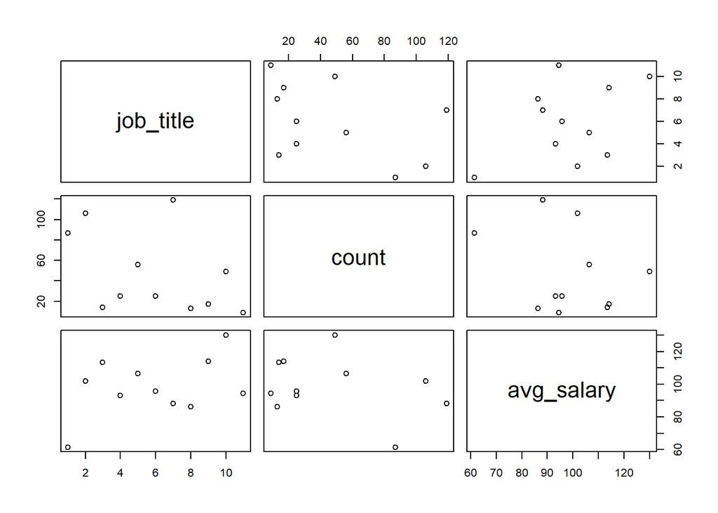

```r
# separate uncommon job titles into a "Other" column
desc_agg_glassdoor <- agg_glassdoor %>% arrange(count)
filterIndex <- max(which(desc_agg_glassdoor$count < 7))
# agg_glassdoor_filtered <- agg_glassdoor %>% mutate(job_title = fct_lump_n(job_title, 7))

# dim(desc_agg_glassdoor) # 37 3
desc_agg_glassdoor_filtered = agg_glassdoor[2:37,]
desc_agg_glassdoor_filtered <- desc_agg_glassdoor_filtered %>% mutate(job_title = as.factor(job_title))

plot(desc_agg_glassdoor_filtered)
```

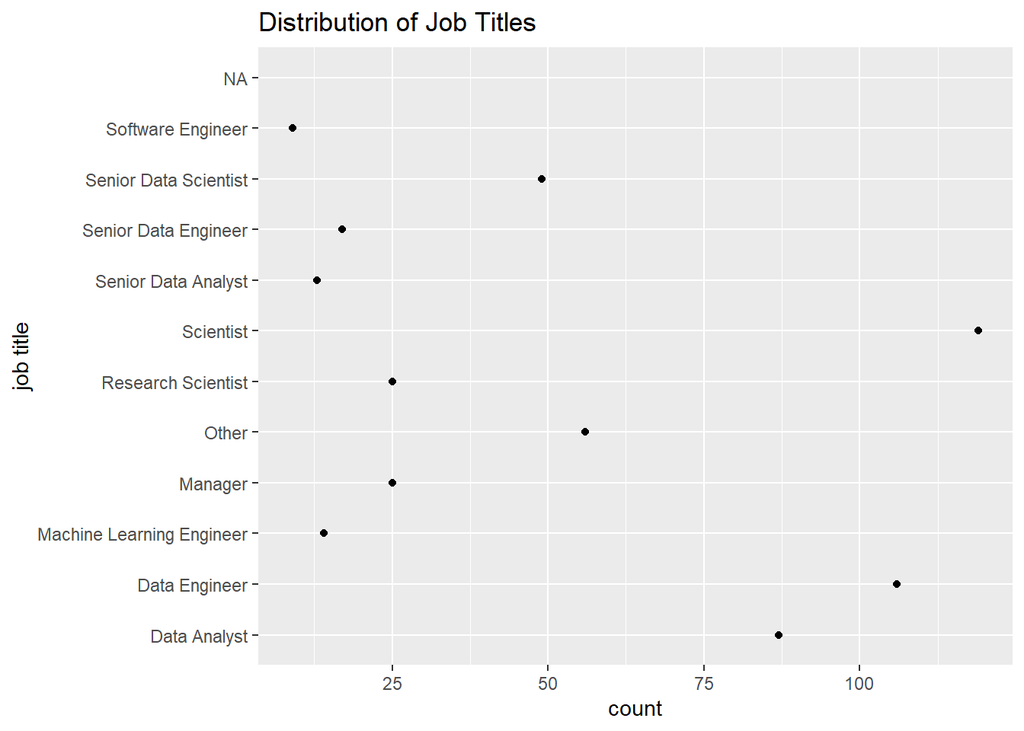

```r
# barplot(desc_agg_glassdoor_filtered$count, main = "Distribution of Job Titles")

desc_agg_glassdoor_filtered %>%
  ggplot(aes(x = count, y = job_title)) +
  geom_point() +
  labs(title = "Distribution of Job Titles", y = "job title" )
```

### Checking for Missing Values

```r
# check missing data
cbind(lapply(lapply(glassdoor, is.na), sum))
```

```
##                   [,1]
## avg_salary        0
## min_salary        0
## max_salary        0
## job_title         0
## rating            0
## size              0
## type_of_ownership 0
## industry          0
## job_state         0
## age               0
## python_yn         0
## r_yn              0
## spark             0
## aws               0
## excel             0
## revenue_low       203
## revenue_high      332
```

## Explanatory Data Analysis

### Average Salary

We’ll first plot average salary to see what kind of trends it has with a histogram.

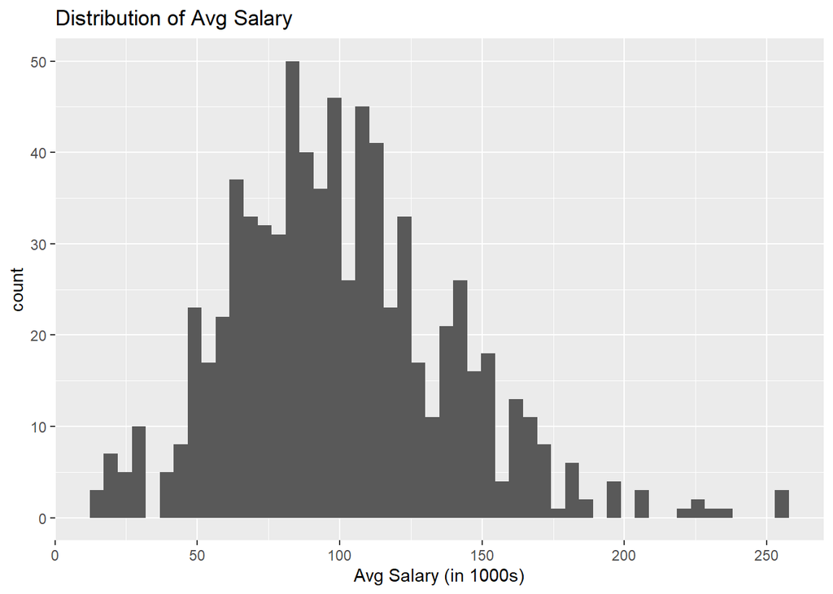

```r
ggplot(glassdoor, aes(x = avg_salary)) +
  geom_histogram(bins = 50) +
  labs( title = "Distribution of Avg Salary", x = "Avg Salary (in 1000s)")
```

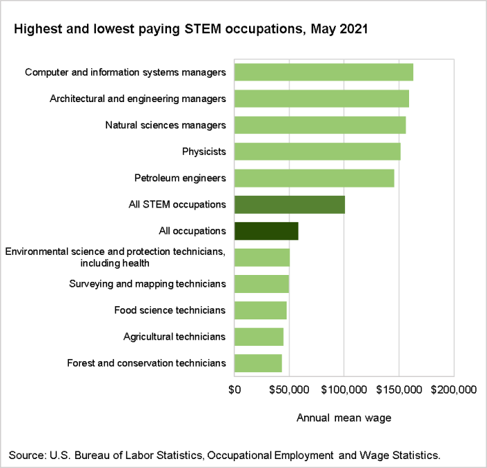

Highest and lowest paying STEM occupations in May 2021, according to BLS

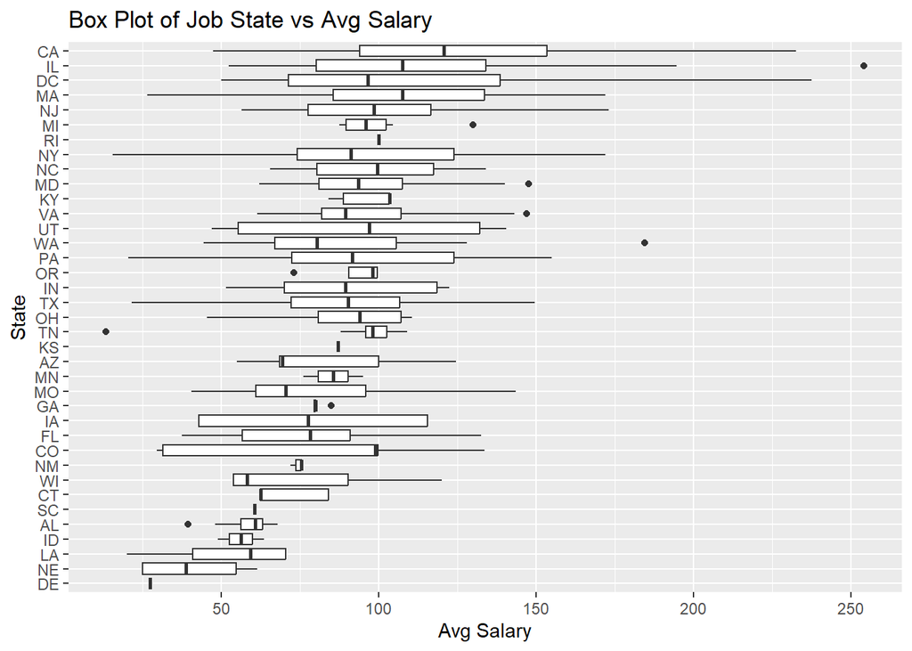

```r
glassdoor %>% ggplot(aes(x = avg_salary, y = reorder(job_state, avg_salary))) +
  geom_boxplot() +
  labs( title = "Box Plot of Job State vs Avg Salary", y = "State", x = "Avg Salary")
```

### Correlation Plot

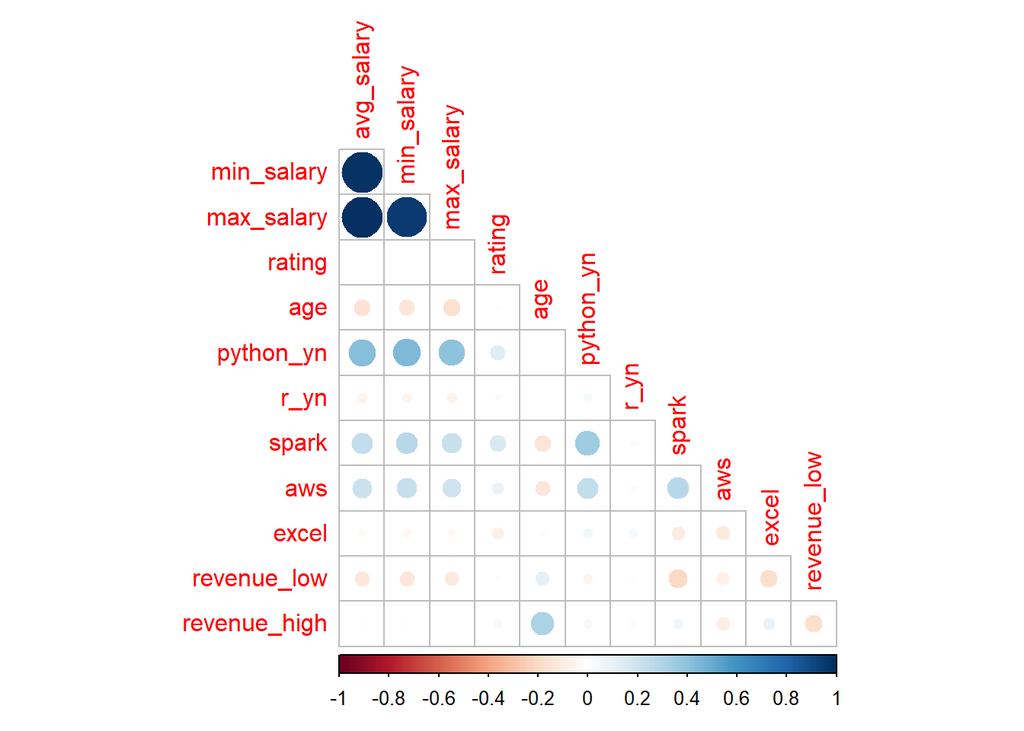

```r
# filter out only numeric values
glassdoor_numeric <- glassdoor %>%
  select(is.numeric)

# correlation matrix
glassdoor_corr <- cor(glassdoor_numeric)

# glassdoor_corrplot <- corrplot(glassdoor_corr, method = "circle", addCoef.col = 1, number.cex = 0.7, diag=FALSE, type = "lower")

glassdoor %>%
  select(where(is.numeric)) %>%
  cor(use = "complete.obs") %>%
  corrplot(type = "lower", diag = FALSE)
```

We have almost no numeric data that’s correlated with `avg_salary`. Since we don’t have many numeric variables a correlation plot does not actually provide much useful information. `min_salary` and `max_salary` is what `avg_salary` is generated from so we ignore that.

We can see that the average salary has almost no correlation with age and Glassdoor rating. It is interesting however to note that `revenue_high` has a mild positive correlation with company `age`. This is most likely due to companies that have been around longer tends to earn higher revenue given that they’ve stayed afloat for longer. `python_yn` is positively correlated with average salary, since Python is a common skill listed as a qualification for data scientists.

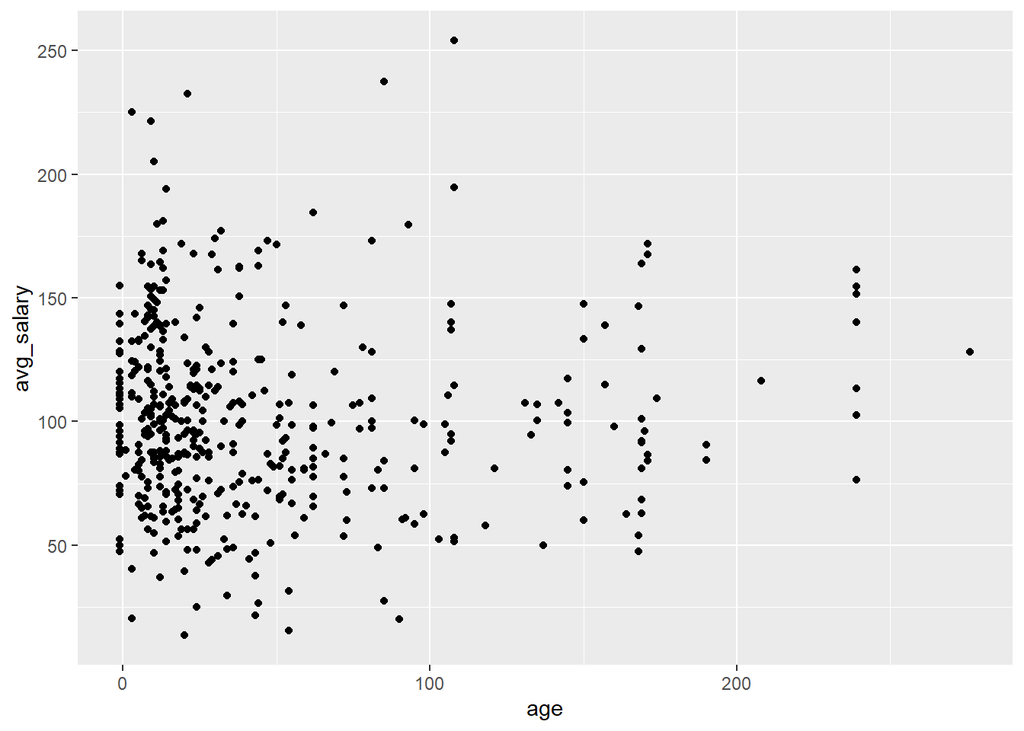

```r
# scatterplot in relation to each predictor
glassdoor %>%
  ggplot(aes(x = age, y = avg_salary)) +
  geom_point()
```

Most of the data is clumped under 50 for company age. Silicon Valley tech companies didn’t really start appearing in what we can consider recent timeline, so this also makes sense. Famous companies like Amazon, Facebook (Meta), Apple, Nvidia, Microsoft, AMD, and so on were not founded until the 1970 - 2000s.

## Model Building

### Converting to Factors

```r
# convert categorical data to factors
glassdoor <- glassdoor %>%
  mutate(job_title = factor(job_title), type_of_ownership = factor(type_of_ownership), industry = factor(industry), job_state = factor(job_state), python_yn = factor(python_yn), r_yn = factor(r_yn), spark = factor(spark), aws = factor(aws), excel = factor(excel))

dim(glassdoor) # 742  17
```

```
## [1] 742  17
```

### Splitting the Data

```r
set.seed(3435)
glassdoor <- glassdoor %>% select(-revenue_low, -revenue_high, -min_salary, -max_salary)

glassdoor_split <- glassdoor %>%
  initial_split(prop = 0.7, strata = "avg_salary")

glassdoor_train <- training(glassdoor_split)
glassdoor_test <- testing(glassdoor_split)
```

### Setting up Recipe

```r
glassdoor_recipe <- recipe(avg_salary ~ rating + size + python_yn + r_yn + spark + aws + excel + job_title + job_state, data=glassdoor_train) %>%
  step_dummy(python_yn, r_yn, spark, aws, excel, size, job_title, job_state) %>%
  step_center((all_predictors())) %>%
  step_scale(all_predictors())
```

### K Fold Cross Validation

We split the model into 5 folds and use cross validation to tune the model and select the best one using `rsme` as the criteria. `rsme` is the square root of MSE, often used to measure differences between observed and predicted values.

```r
# set.seed(11)
glassdoor_folds <- vfold_cv(glassdoor_train, v = 5, strata = "avg_salary")
```

### Fitting the Models

steps: setup model by specifying model you want to fit, tuning parameters, engine, and mode (regression) set up workflow for the model, add model to recipe create tuning grid to specify range of params you want to tune and # levels save tuned models to RDS file so we don’t have to rerun it load back saved fiels collect metrics of tuned models, arrange in ascending order of mean to see lowest RMSE for the tuned model, and slice to choose loweset RMSE. save the RMSE value for further comparison

```r
# linear regression
lm_model <- linear_reg() %>%
  set_engine("lm")

# workflow
lm_workflow <- workflow() %>%
  add_model(lm_model) %>%
  add_recipe(glassdoor_recipe)

# linear regression has no tuning parameters

# ridge regression: penalty, mixture = 0
ridge_spec <- linear_reg(mixture = 0, penalty = tune()) %>%
  set_mode("regression") %>%
  set_engine("glmnet")

ridge_workflow <- workflow() %>%
  add_recipe(glassdoor_recipe) %>%
  add_model(ridge_spec)

# tuning
penalty_grid <- grid_regular(penalty(range = c(-5,5)), levels = 50)

# lasso
lasso_spec <- linear_reg(penalty = tune(), mixture = 1) %>%
  set_mode("regression") %>%
  set_engine("glmnet")

lasso_workflow <- workflow() %>%
  add_recipe(glassdoor_recipe) %>%
  add_model(lasso_spec)

# lasso uses same grid as ridge

# k nearest neighbors
knn_model <- nearest_neighbor(neighbors = tune()) %>%
  set_mode("regression") %>%
  set_engine("kknn")

knn_workflow <- workflow() %>%
  add_model(knn_model) %>%
  add_recipe(glassdoor_recipe)

knn_grid <- grid_regular(neighbors(range = c(1,15)), levels = 5)

# random forest
rf_model <- rand_forest(mtry = tune(), trees = tune(), min_n = tune()) %>%
  set_engine("ranger", importance = "impurity") %>%
  set_mode("regression")

rf_workflow <- workflow() %>%
  add_recipe(glassdoor_recipe) %>%
  add_model(rf_model)

rf_parameter_grid <- grid_regular(mtry(range = c(1, 12)), trees(range = c(200,1000)), min_n(range = c(5,20)), levels = 8)

# boosted trees
boosted_model <- boost_tree(trees = tune(), learn_rate = tune(), min_n = tune()) %>%
  set_engine("xgboost") %>%
  set_mode("regression")

boosted_workflow <- workflow() %>%
  add_recipe(glassdoor_recipe) %>%
  add_model(boosted_model)

boosted_grid <- grid_regular(trees(range = c(5, 200)), learn_rate(range = c(0.01,0.1), trans = identity_trans()), min_n(range = c(40, 60)), levels = 5)
```

### Model Tuning

```r
# linear regression does not need tuning

# ridge
# ridge_tune <- tune_grid(
#   ridge_workflow,
#   resamples = glassdoor_folds,
#   grid = penalty_grid)
#
# #lasso
# lasso_tune <- tune_grid(
#   lasso_workflow,
#   resamples = glassdoor_folds,
#   grid = penalty_grid)
#
# #k nearest neighbors
# knn_tune <- tune_grid(
#     knn_workflow,
#     resamples = glassdoor_folds,
#     grid = knn_grid)
#
# # random forest
# rf_tune_res <- tune_grid(
#   rf_workflow,
#   resamples = glassdoor_folds,
#   grid = rf_parameter_grid)
#
# # boosted trees
# boosted_tune_res <- tune_grid(
#   boosted_workflow,
#   resamples = glassdoor_folds,
#   grid = boosted_grid)
```

```r
# save tuned models so we don't need to rerun them
# write_rds(ridge_tune, file = "C:/Users/olivi/Documents/ucsb winter 2023/pstat 131/final project/data/processed/ridge2.rds")
# write_rds(lasso_tune, file = "C:/Users/olivi/Documents/ucsb winter 2023/pstat 131/final project/data/processed/lasso2.rds")
# write_rds(knn_tune, file = "C:/Users/olivi/Documents/ucsb winter 2023/pstat 131/final project/data/processed/knn2.rds")
# write_rds(rf_tune_res, file = "C:/Users/olivi/Documents/ucsb winter 2023/pstat 131/final project/data/processed/rf2.rds")
# write_rds(boosted_tune_res, file = "C:/Users/olivi/Documents/ucsb winter 2023/pstat 131/final project/data/processed/boosted2.rds")
```

```r
# load back saved files
ridge_tuned <- read_rds(file = "C:/Users/olivi/Documents/ucsb winter 2023/pstat 131/final project/data/processed/ridge2.rds")
lasso_tuned <- read_rds(file = "C:/Users/olivi/Documents/ucsb winter 2023/pstat 131/final project/data/processed/lasso2.rds")
knn_tuned <- read_rds(file = "C:/Users/olivi/Documents/ucsb winter 2023/pstat 131/final project/data/processed/knn2.rds")
rf_tuned <- read_rds(file = "C:/Users/olivi/Documents/ucsb winter 2023/pstat 131/final project/data/processed/rf2.rds")
boosted_tuned <- read_rds(file = "C:/Users/olivi/Documents/ucsb winter 2023/pstat 131/final project/data/processed/boosted2.rds")
```

```r
# collect metrics and slice to save rmse
# linear regression
lm_fit <- fit_resamples(lm_workflow, resamples = glassdoor_folds)
lm_rmse <- collect_metrics(lm_fit) %>% slice(1)
lm_rmse
```

| .metric | .estimator | mean | n | std_err | .config |
| --- | --- | --- | --- | --- | --- |
| rmse | standard | 32.15 | 5 | 1.335 | Preprocessor1_Model1 |

```r
# ridge
ridge_rmse <- collect_metrics(ridge_tuned) %>%
  arrange(mean) %>% slice(49)
ridge_rmse
```

| penalty | .metric | .estimator | mean | n | std_err | .config |
| --- | --- | --- | --- | --- | --- | --- |
| 4.095e-05 | rmse | standard | 32.15 | 5 | 1.472 | Preprocessor1_Model04 |

```r
# lasso
lasso_rmse <- collect_metrics(lasso_tuned) %>%
  arrange(mean) %>% slice(35)
lasso_rmse
```

| penalty | .metric | .estimator | mean | n | std_err | .config |
| --- | --- | --- | --- | --- | --- | --- |
| 0.1207 | rmse | standard | 31.96 | 5 | 1.413 | Preprocessor1_Model21 |

```r
#
# knn
knn_rmse <- collect_metrics(knn_tuned) %>%
  arrange(mean) %>% slice(6)
knn_rmse
```

| neighbors | .metric | .estimator | mean | n | std_err | .config |
| --- | --- | --- | --- | --- | --- | --- |
| 4 | rmse | standard | 31.61 | 4 | 1.372 | Preprocessor1_Model2 |

```r
# random forest
rf_rmse <- collect_metrics(rf_tuned) %>%
  arrange(mean) %>% slice(513)
rf_rmse
```

| mtry | trees | min_n | .metric | .estimator | mean | n | std_err | .config |
| --- | --- | --- | --- | --- | --- | --- | --- | --- |
| 12 | 314 | 5 | rmse | standard | 28.24 | 4 | 1.416 | Preprocessor1_Model016 |

```r
# boosted trees
boosted_rmse <- collect_metrics(boosted_tuned) %>%
  arrange(mean) %>% slice(126)
boosted_rmse
```

| trees | min_n | learn_rate | .metric | .estimator | mean | n | std_err | .config |
| --- | --- | --- | --- | --- | --- | --- | --- | --- |
| 200 | 40 | 0.1 | rmse | standard | 32.92 | 5 | 1.788 | Preprocessor1_Model105 |

## Model Results

We pick the model based off the lowest mean RMSE. From the performance of the models based off the cross-validation data, random forest performed the best.

```r
model <- c('Linear Regression', 'Ridge Regression', 'Lasso Regression', 'K nearest Neighbors', 'Random Forest', "Boosted Trees")
RMSE <- c(32.15, 32.15, 31.96, 31.61, 28.24, 32.92)
data.frame(model, RMSE) %>% arrange(RMSE)
```

| model | RMSE |
| --- | --- |
| Random Forest | 28.24 |
| K nearest Neighbors | 31.61 |
| Lasso Regression | 31.96 |
| Linear Regression | 32.15 |
| Ridge Regression | 32.15 |
| Boosted Trees | 32.92 |

### Model Autoplots

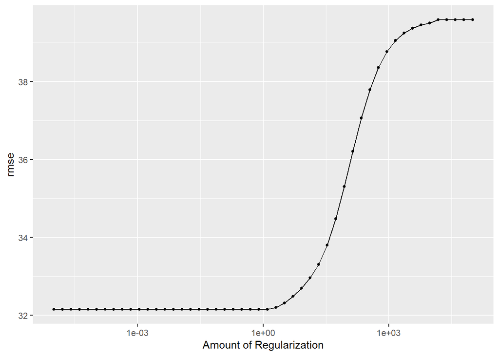

```r
# ridge
autoplot(ridge_tuned, metric = "rmse")
```

K nearest Neighbors: Except for the start which is a constant rate of decrease, as number of neighbors increases, rmse also increases. The lowest rmse appears at the beginning, when neighbor = 4.

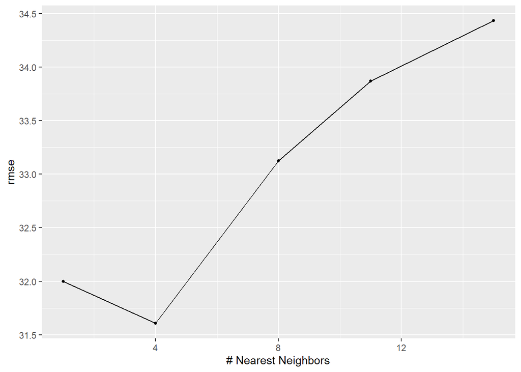

```r
# knn
autoplot(knn_tuned, metric = "rmse")
```

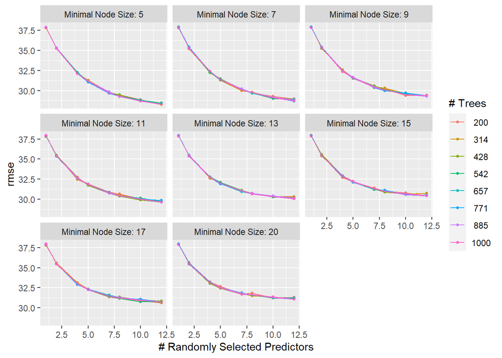

```r
# random forest
autoplot(rf_tuned, metric = "rmse")
```

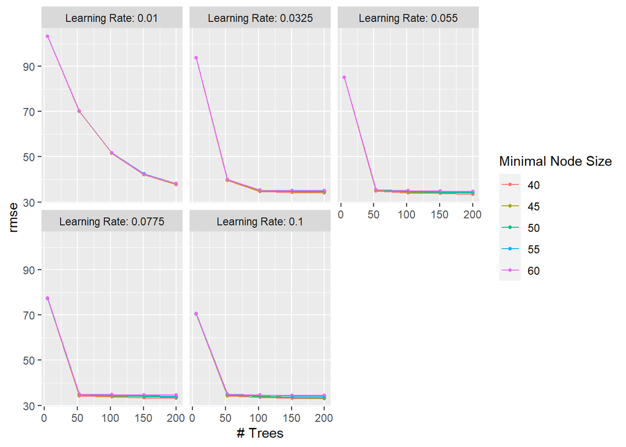

```r
# boosted trees
autoplot(boosted_tuned, metric = "rmse")
```

```r
#select the best model
final_model <- select_best(rf_tuned)

#set up workflow for the last model
final_workflow <- finalize_workflow(rf_workflow, final_model)

#fit the model to the training set
final_fit <- fit(final_workflow, data = glassdoor_train)

#Evaluate the model performance on the testing set
multi_metric <- metric_set(rmse, rsq, mae)
final_predict <- predict(final_fit, glassdoor_test) %>%
  bind_cols(glassdoor_test %>% select(avg_salary))
multi_metric(final_predict, truth = avg_salary, estimate = .pred)
```

| .metric | .estimator | .estimate |
| --- | --- | --- |
| rmse | standard | 24.524 |
| rsq | standard | 0.572 |
| mae | standard | 17.994 |

## Variable Importance

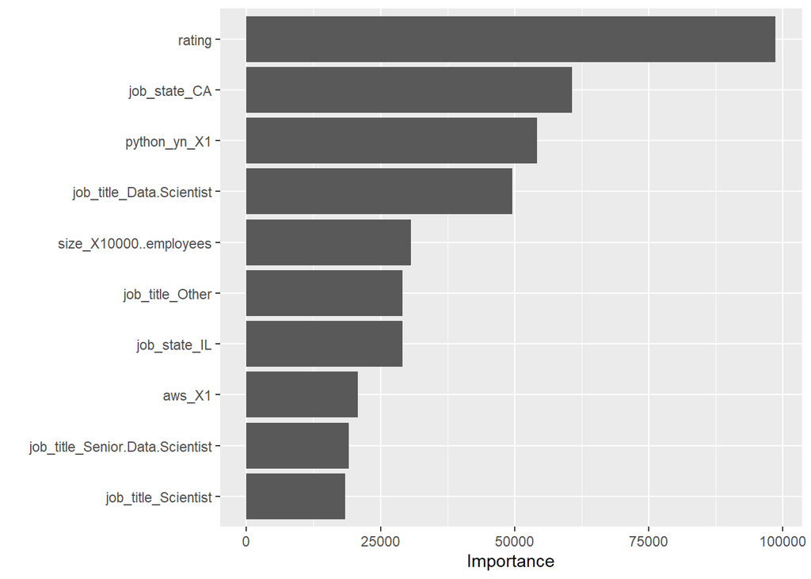

```r
final_fit %>% extract_fit_engine() %>% vip()
```

As expected, we see that rating is the most important variable, followed by working in California and knowing Python, perhaps the most common qualification listed for Data scientists.

## Conclusion

In conclusion, the best performing model is random forest in comparison to linear regression, lasso, ridge, k-nearest neighbors, and boosted trees. This does not come across as a surprise since random forest is the best fitting model for a lot of data as it is a nonparametric, so it makes no assumptions on outcomes or distributions. However, since the rmse was so high it appears the model doesn’t actually perform that well.

It is unexpected that the other skillsets are not considered as important, like Spark. I was under the impression that tech jobs usually list many qualifications, with many of them being the same, so I was surprised that they were not of higher importance.

Overall, the conclusions we reached were pretty much along the lines of what I expected; data science jobs in california looking for Python as a key skill has the highest average salary. However, due to the high rmse value it appears our model does a poor job at predicting average salary on Glassdoor.